# Monthly Sales Report

Published

June 22, 2026

## Summary

- **Total revenue:** $822,037.04 across 4644 orders
- **Best month:** 2024-12 with $97,138.60 in revenue (561 orders)
- **Period covered:** 2024-07 to 2025-06

## Revenue by Month

| Month | Orders | Revenue |
| --- | --- | --- |
| 2024-07 | 270 | $44,576.74 |
| 2024-08 | 279 | $49,082.12 |
| 2024-09 | 312 | $54,801.47 |
| 2024-10 | 379 | $69,105.66 |
| 2024-11 | 489 | $83,957.86 |
| 2024-12 | 561 | $97,138.60 |
| 2025-01 | 311 | $55,698.25 |
| 2025-02 | 341 | $59,410.83 |
| 2025-03 | 408 | $74,369.75 |
| 2025-04 | 438 | $74,904.37 |
| 2025-05 | 438 | $78,555.52 |
| 2025-06 | 418 | $80,435.87 |

## Revenue Trend

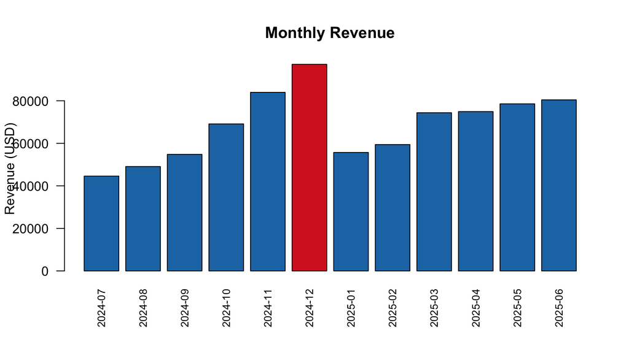

The chart makes the shape of the year obvious at a glance: a smooth ramp-up through the second half of 2024, a single red bar marking the **2024-12** peak (highlighted in the plot), and then a one-month cliff in January 2025 before revenue resumes climbing through the first half of 2025. No other month comes close to matching the post-holiday drop in either direction — the rest of the series moves in comparatively small, gradual steps.

## Discussion

**Seasonality, not pricing, drives the peak.** Average order value (AOV) stays in a narrow $165–$192 band all year (165 to 192 USD), while order counts range from 270 to 561 — roughly double. December’s record revenue is therefore explained almost entirely by order *volume* (561 orders, the most of any month), not by customers spending more per order. This is consistent with a holiday shopping effect rather than a pricing or promotion change.

**Underlying trend is positive across halves.** Total revenue for the second half of 2024 (Jul–Dec) was $398,662.45, versus $423,374.59 for the first half of 2025 — a 6.2% increase despite H1 2025 having no equivalent holiday spike, suggesting the business is growing its baseline (non-holiday) demand, not just riding a one-time seasonal event.

**Limitations.** This analysis uses gross revenue (`quantity × unit_price`) with no adjustment for returns, discounts, or refunds, and only twelve months are available, so the “seasonal” interpretation of the December peak cannot be confirmed without a second holiday cycle to compare against.

## Conclusion

Revenue grew steadily over the period, with a clear seasonal peak in **2024-12**, driven by higher order volume (561 orders) rather than higher spending per order. The sharp pullback in the following month was temporary, and the underlying revenue trend across the full year remained positive.